# 데이터 가져오기

[문자인식(OCR) - `tesseract`

xwMOOC

2019-04-30

# 1 `tesseract` 문자인식

[`tesseract`](https://opensource.google.com/projects/tesseract)를 통해서 100개가 넘는 언어를 사용해서 문서에 포함된 문자를 인식시킬 있는 광학 문자 판독 (optical character recognition, OCR) 엔진이다.

# 2 `tesseract` 헬로월드

[tesseract 소품문](https://cran.r-project.org/web/packages/tesseract/vignettes/intro.html)에 포함된 영문 예제로부터 시작해보자. 아래 영문에서 텍스트를 추출할 수 있다.

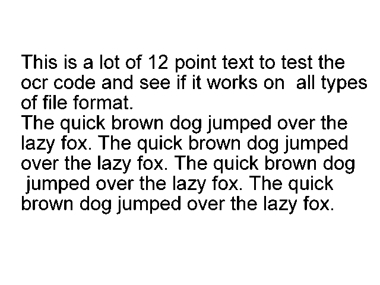

```r
library(tidyverse)
library(tesseract)

eng <- tesseract("eng")
text <- tesseract::ocr("http://jeroen.github.io/images/testocr.png", engine = eng)
cat(text)
```

```
This is a lot of 12 point text to test the
ocr code and see if it works on all types
of file format.

The quick brown dog jumped over the
lazy fox. The quick brown dog jumped
over the lazy fox. The quick brown dog
jumped over the lazy fox. The quick
brown dog jumped over the lazy fox.
```

# 3 `tesseract` 텍스트 위치

상기 이미지에서 추출된 단어에 대한 위치정보가 포함되어 있다.

```r
results <- tesseract::ocr_data("http://jeroen.github.io/images/testocr.png", engine = eng)
results %>%
  DT::datatable()
```

|  | word | confidence | bbox |
| --- | --- | --- | --- |
| 1 | This | 96.5907669067383 | 36,92,96,116 |
| 2 | is | 96.9154205322266 | 109,92,129,116 |
| 3 | a | 96.33154296875 | 141,98,156,116 |
| 4 | lot | 96.33154296875 | 169,92,201,116 |
| 5 | of | 96.4535446166992 | 212,92,240,116 |
| 6 | 12 | 96.4535446166992 | 251,92,282,116 |
| 7 | point | 96.4696350097656 | 296,92,364,122 |
| 8 | text | 96.4696350097656 | 374,93,427,116 |
| 9 | to | 96.8844223022461 | 437,93,463,116 |
| 10 | test | 96.9844284057617 | 474,93,526,116 |

[output cut: 50 more lines]

가장 문자인식율이 높은 단어는 `test`로 96.9844284057617, 가장 낮은 단어는 `on` 93.5358657836914으로 나타난다. 이를 `bbox` 정보가 함께 제공되니 이를 이미지에 겹쳐 보자. 이를 위해서 [`magick`](https://cran.r-project.org/web/packages/magick/vignettes/intro.html) 팩키지를 활용하여 구현해보자.

동일한 문서를 가져와서 `image_draw()` 함수로 기존 이미지위에 도형을 올릴 수 있다. `tesseract::ocr_data()` 함수를 사용해서 이미지에서 인식한 텍스트 위치를 특정시킬 수 있고 그 정보는 `bbox` 칼럼에 저장된다. 앞서 가장 인식이 잘 된 것이라고 판단된 단어와 반대 단어를 추출하여 이를 단어 박스를 씌워보자.

```r
library(magick)
document_ocr <- image_read('http://jeroen.github.io/images/testocr.png')

document_box <- image_draw(document_ocr)

results_df <- results %>%
  mutate(loc = str_split(bbox, ",")) %>%
  mutate(top_x = map_chr(loc, 1),
         top_y = map_chr(loc, 2),
         bottom_x = map_chr(loc, 3),
         bottom_y = map_chr(loc, 4))

(most_conf <- results_df %>%
  top_n(1, wt=confidence) )
```

```
# A tibble: 1 x 8
  word  confidence bbox           loc       top_x top_y bottom_x bottom_y
  <chr>      <dbl> <chr>          <list>    <chr> <chr> <chr>    <chr>
1 test        97.0 474,93,526,116 <chr [4]> 474   93    526      116
```

```r
(least_conf <- results_df %>%
  arrange(confidence) %>%
  head(1) )
```

```
# A tibble: 1 x 8
  word  confidence bbox            loc       top_x top_y bottom_x bottom_y
  <chr>      <dbl> <chr>           <list>    <chr> <chr> <chr>    <chr>
1 on          93.5 445,132,478,150 <chr [4]> 445   132   478      150
```

```r
rect(most_conf$top_x, most_conf$top_y, most_conf$bottom_x, most_conf$bottom_y, border = "blue", lty = "solid", lwd = 3)

rect(least_conf$top_x, least_conf$top_y, least_conf$bottom_x, least_conf$bottom_y, border = "red", lty = "solid", lwd = 3)

dev.off()
```

```r
print(document_box)
```

```
# A tibble: 1 x 7
  format width height colorspace matte filesize density
  <chr>  <int>  <int> <chr>      <lgl>    <int> <chr>
1 PNG      640    480 sRGB       TRUE         0 72x72
```

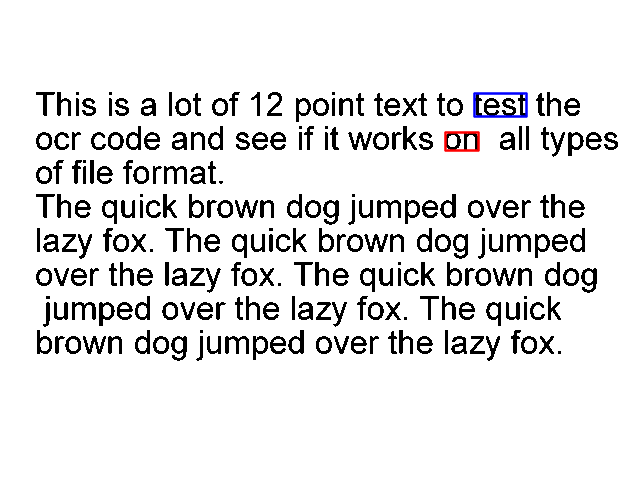

# 4 한국어 인식

웹사이트에 공개된 [국문계약서 샘플 - 14, 특허 및 기술 도입 라이선스 계약서 샘플 – License and Distribution Agre…](http://kasanlaw.com/bbs/board.php?bo_table=sub04_1&wr_id=132)을 다운로드 받아 한국어 문자인식 작업을 추진해보자.

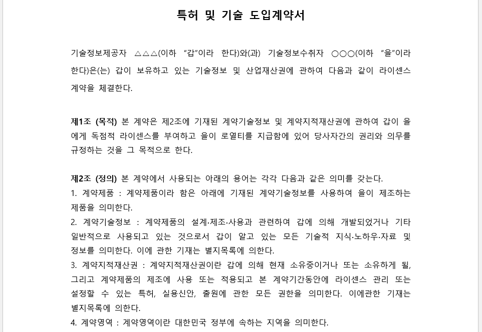

## 4.1 한국어 설정

먼저 [tesseract ocr](https://github.com/tesseract-ocr/tesseract/wiki/Data-Files) 한국어 데이터를 다운로드 받아 설치한다. `tesseract_info()$available` 명령어를 통해 한국어 엔진이 설치된 것을 확인한다.

```r
# tesseract_download("kor")
tesseract_info()$available
```

```
[1] "eng" "kor" "osd"
```

## 4.2 한국어 문자 인식 설정

`tesseract::ocr` 명령어에 더해서 `engine = kor`을 설정하게 되면 문서의 한국어를 인식하게 된다.

```r
kor <- tesseract("kor")
contract_text <- tesseract::ocr("fig/ocr-contract-sample.png", engine = kor)

contract_text
```

```
[1] "특허 및 기술 도입계약서\n기술정보제공자 스스스(이하 \"갑\"이라 한다)와(과) 기술정보수취자 ㅠㅇㅇ(이하 “을\"이라\n한다)은(는) 갑이 보유하고 있는 기술정보 및 산업재산권에 관하여 다음과 같이 라이센스\n계약을 체결한다,\n제1조 (목적) 본 계약은 제2조에 기재된 계약기술정보 및 계약지적재산권에 관하여 감이 을\n에게 독점적 라이센스를 부여하고 을이 로열티를 지급함에 있어 당사자간의 권리와 의무를\n규정하는 것을 그 목적으로 한다\n제2조 (정의) 본 계약에서 사용되는 아래의 용어는 각각 다음과 같은 의미를 갖는…
```

## 4.3 문자 인식 신뢰도

영문과 동일하게 한국어 문자 인식 신뢰도를 파악한다.

```r
contract_df <- tesseract::ocr_data("fig/ocr-contract-sample.png", engine = kor)
contract_df %>%
  DT::datatable()
```

|  | word | confidence | bbox |
| --- | --- | --- | --- |
| 1 | 특허 | 96.7730484008789 | 353,20,394,41 |
| 2 | 및 | 96.9853973388672 | 411,20,428,41 |
| 3 | 기술 | 93.2774429321289 | 443,20,484,41 |
| 4 | 도 | 93.2465515136719 | 499,22,518,38 |
| 5 | 입 | 93.2648315429688 | 522,20,539,40 |
| 6 | 계약서 | 97.0026321411133 | 544,20,606,41 |
| 7 | 기 | 93.2766036987305 | 143,99,155,114 |
| 8 | 술 | 91.6031188964844 | 158,99,172,113 |
| 9 | 정 | 92.8816909790039 | 174,99,187,113 |
| 10 | 보 | 93.2685852050781 | 190,100,204,111 |

[output cut: 372 more lines]

## 4.4 문자 인식 신뢰도

인식된 문자에 대한 신뢰도 파악을 위해서 계약서 이미지에 가장 잘 인식된 문자와 그렇지 않는 문자를 시각화한다.

```r
contract_ocr <- image_read('fig/ocr-contract-sample.png')

contract_box <- image_draw(contract_ocr)

contract_df <- contract_df %>%
  mutate(loc = str_split(bbox, ",")) %>%
  mutate(top_x = map_chr(loc, 1),
         top_y = map_chr(loc, 2),
         bottom_x = map_chr(loc, 3),
         bottom_y = map_chr(loc, 4))

(most_conf <- contract_df %>%
  top_n(1, wt=confidence) )
```

```
# A tibble: 1 x 8
  word  confidence bbox            loc       top_x top_y bottom_x bottom_y
  <chr>      <dbl> <chr>           <list>    <chr> <chr> <chr>    <chr>
1 는          97.0 498,350,512,364 <chr [4]> 498   350   512      364
```

```r
(least_conf <- contract_df %>%
  arrange(confidence) %>%
  head(1) )
```

```
# A tibble: 1 x 8
  word  confidence bbox            loc       top_x top_y bottom_x bottom_y
  <chr>      <dbl> <chr>           <list>    <chr> <chr> <chr>    <chr>
1 제          32.9 415,437,432,452 <chr [4]> 415   437   432      452
```

```r
rect(most_conf$top_x, most_conf$top_y, most_conf$bottom_x, most_conf$bottom_y, border = "blue", lty = "solid", lwd = 3)

rect(least_conf$top_x, least_conf$top_y, least_conf$bottom_x, least_conf$bottom_y, border = "red", lty = "solid", lwd = 3)

dev.off()
```

```r
print(contract_box)
```

```
# A tibble: 1 x 7
  format width height colorspace matte filesize density
  <chr>  <int>  <int> <chr>      <lgl>    <int> <chr>
1 PNG      962    664 sRGB       TRUE         0 38x38
```

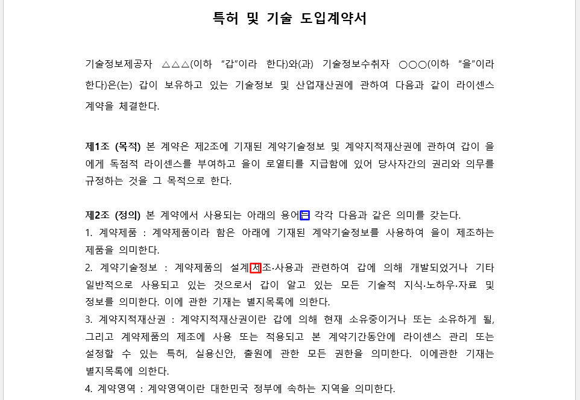